# R Notebook

```r
setwd("C:/Users/linan/Documents/GitHub/project/R-project/Regression-R")
COPDStudentc.df <- read.table(file="COPD_student_dataset.csv", header=TRUE, dec=".", sep = ",")
```

Correlation between MWT1Best and FEV1

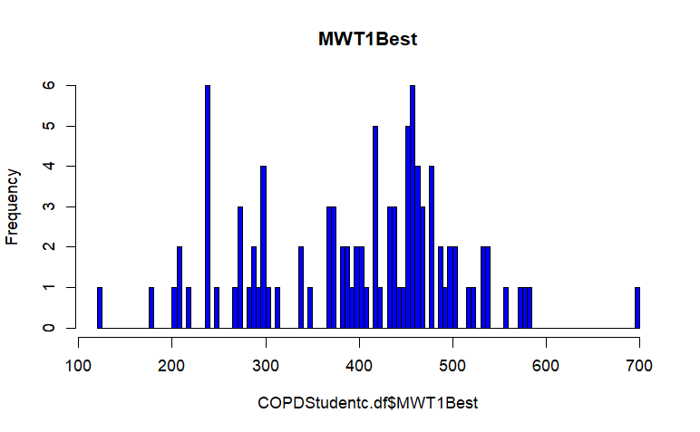

```r
COPDStudentc.df$MWT1Best<-as.numeric(COPDStudentc.df$MWT1Best)
hist(COPDStudentc.df$MWT1Best, main="MWT1Best", col="blue", breaks=100)
```

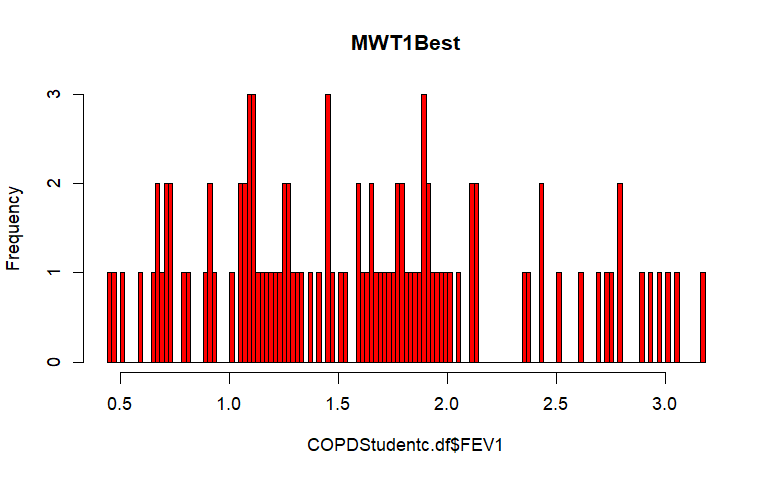

```r
hist(COPDStudentc.df$FEV1, main="MWT1Best", col="red", breaks=100)
```

```r
subset(COPDStudentc.df, MWT1Best > 600 | MWT1Best < 150)
```

|  | X | ID | AGE | PackHistory | COPDSEVERITY | MWT1 | MWT2 | MWT1Best | FEV1 | FEV1PRED | FVC | FVCPRED | CAT | HAD | SGRQ | AGEquartiles | copd | gender | smoking | Diabetes | muscular | hypertension | AtrialFib | IHD |
| --- | --- | --- | --- | --- | --- | --- | --- | --- | --- | --- | --- | --- | --- | --- | --- | --- | --- | --- | --- | --- | --- | --- | --- | --- |
| 1 | 1 | 58 | 77 | 60 | SEVERE | 120 | 120 | 120 | 1.21 | 36 | 2.40 | 98 | 25 | 8 | 69.55 | 4 | 3 | 1 | 2 | 1 | 0 | 0 | 1 | 0 |
| 100 | 100 | 108 | 54 | 30 | SEVERE | 688 | 699 | 699 | 1.72 | 44 | 4.07 | 82 | 10 | 10 | 20.55 | 1 | 3 | 1 | 2 | 0 | 0 | 0 | 0 | 0 |

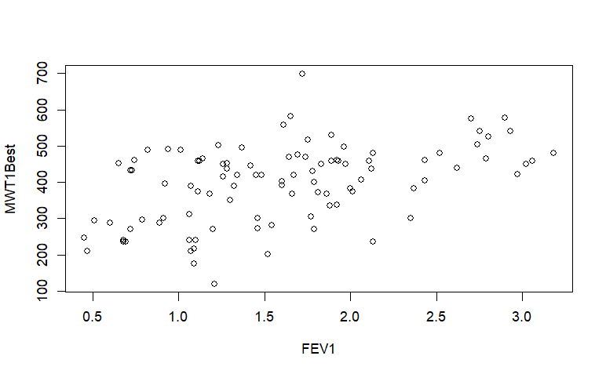

```r
plot(COPDStudentc.df$FEV1, COPDStudentc.df$MWT1Best, xlab = "FEV1", ylab = "MWT1Best")
```

```r
cor.test(COPDStudentc.df$FEV1, COPDStudentc.df$MWT1Best, use="complete.obs", method = "pearson")
```

```
    Pearson's product-moment correlation

data:  COPDStudentc.df$FEV1 and COPDStudentc.df$MWT1Best
t = 5.26, df = 98, p-value = 8.469e-07
alternative hypothesis: true correlation is not equal to 0
95 percent confidence interval:
 0.3004898 0.6094629
sample estimates:
      cor
0.4692142
```

```r
cor.test(COPDStudentc.df$FEV1, COPDStudentc.df$MWT1Best, use="complete.obs", method = "spearman")
```

```
    Spearman's rank correlation rho

data:  COPDStudentc.df$FEV1 and COPDStudentc.df$MWT1Best
S = 90853, p-value = 1.995e-06
alternative hypothesis: true rho is not equal to 0
sample estimates:
      rho
0.4548251
```

Walking Distance and Age

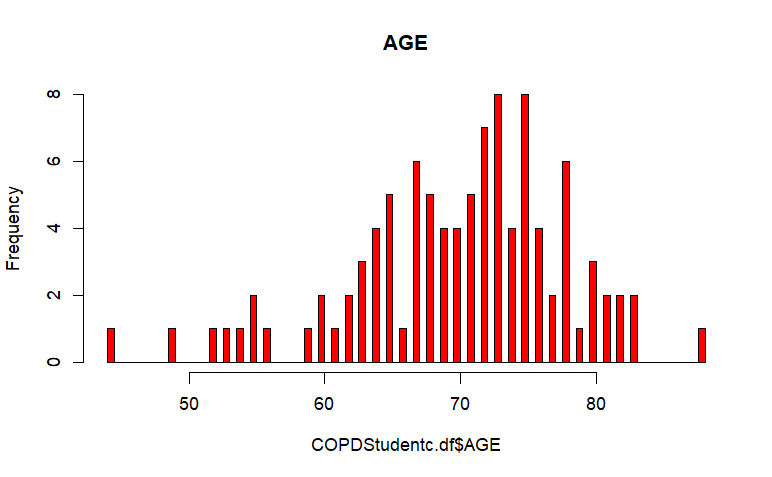

```r
hist(COPDStudentc.df$AGE, main="AGE", col="red", breaks=100)
```

```r
cor.test(COPDStudentc.df$AGE,
         COPDStudentc.df$MWT1Best,
         use="complete.obs",
         method = "pearson")
```

```
    Pearson's product-moment correlation

data:  COPDStudentc.df$AGE and COPDStudentc.df$MWT1Best
t = -2.3406, df = 98, p-value = 0.02128
alternative hypothesis: true correlation is not equal to 0
95 percent confidence interval:
 -0.4080687 -0.0352688
sample estimates:
      cor
-0.230093
```

```r
cor.test(COPDStudentc.df$AGE,
         COPDStudentc.df$MWT1Best,
         use="complete.obs",
         method = "spearman")
```

```
    Spearman's rank correlation rho

data:  COPDStudentc.df$AGE and COPDStudentc.df$MWT1Best
S = 211497, p-value = 0.006781
alternative hypothesis: true rho is not equal to 0
sample estimates:
       rho
-0.2691106
```

```r
cor.test(COPDStudentc.df$FVC,
         COPDStudentc.df$MWT1Best,
         use="complete.obs",
         method = "pearson")
```

```
    Pearson's product-moment correlation

data:  COPDStudentc.df$FVC and COPDStudentc.df$MWT1Best
t = 4.9289, df = 98, p-value = 3.368e-06
alternative hypothesis: true correlation is not equal to 0
95 percent confidence interval:
 0.2732018 0.5904320
sample estimates:
      cor
0.4457027
```

```r
cor.test(COPDStudentc.df$AGE,
         COPDStudentc.df$FEV1,
         use="complete.obs",
         method = "pearson")
```

```
    Pearson's product-moment correlation

data:  COPDStudentc.df$AGE and COPDStudentc.df$FEV1
t = -1.0214, df = 99, p-value = 0.3095
alternative hypothesis: true correlation is not equal to 0
95 percent confidence interval:
 -0.29173893  0.09521727
sample estimates:
       cor
-0.1021224
```

```r
cor.test(COPDStudentc.df$FVC,
         COPDStudentc.df$FEV1,
         use="complete.obs",
         method = "pearson")
```

```
    Pearson's product-moment correlation

data:  COPDStudentc.df$FVC and COPDStudentc.df$FEV1
t = 14.264, df = 99, p-value < 2.2e-16
alternative hypothesis: true correlation is not equal to 0
95 percent confidence interval:
 0.7439801 0.8753003
sample estimates:
     cor
0.820165
```

Check if lung function is a predictor of walking distance in COPD patients :

```r
MWT1Best_FEV1 <- lm(MWT1Best~FEV1, data= COPDStudentc.df)
```

```r
summary(MWT1Best_FEV1)
```

```
Call:
lm(formula = MWT1Best ~ FEV1, data = COPDStudentc.df)

Residuals:
     Min       1Q   Median       3Q      Max
-249.592  -58.227    7.881   63.551  291.612

Coefficients:
            Estimate Std. Error t value Pr(>|t|)
(Intercept)   279.92      24.55   11.40  < 2e-16 ***
FEV1           74.11      14.09    5.26 8.47e-07 ***
---
Signif. codes:  0 ‘***’ 0.001 ‘**’ 0.01 ‘*’ 0.05 ‘.’ 0.1 ‘ ’ 1

Residual standard error: 94.57 on 98 degrees of freedom
  (1 observation deleted due to missingness)
Multiple R-squared:  0.2202,    Adjusted R-squared:  0.2122
F-statistic: 27.67 on 1 and 98 DF,  p-value: 8.469e-07
```

See the confident interval :

```r
confint(MWT1Best_FEV1)
```

```
                2.5 %   97.5 %
(Intercept) 231.19004 328.6456
FEV1         46.15031 102.0710
```

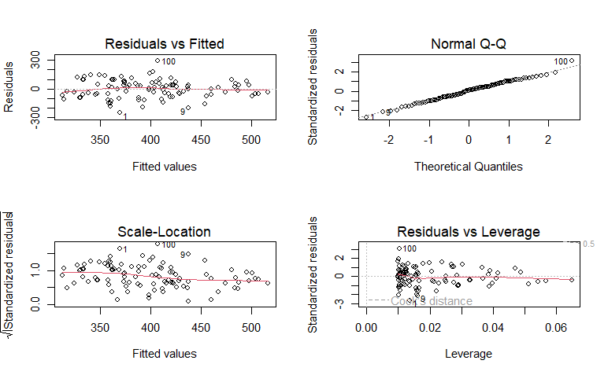

```r
par(mfrow=c(2,2))
plot(MWT1Best_FEV1)
```

To check model assumptions, you can graphically examine the linear regression model using the function plot(). This function allows to check for linearity, homoscedasticity, independence, and normality of your assumptions. Four plots are generated:

1. The first is a constant variance plot, which checks for the homogeneity of the variance and the linear relation. If you see no pattern in this graph, then your assumptions are met.
2. The second plot is a Q-Q plot, which checks that the residuals follow a normal distribution. The points should fall on a line if the normality assumption is met.
3. The third plot allows to detect heterogeneity of the variance.
4. The fourth plot allows for the detection of points that have a large impact on the regression coefficients.

Check if AGE is a predictor of walking distance in COPD patients :

```r
MWTBest1_AGE <- lm(MWT1Best~AGE, data = COPDStudentc.df)
```

```r
summary(MWTBest1_AGE)
```

```
Call:
lm(formula = MWT1Best ~ AGE, data = COPDStudentc.df)

Residuals:
    Min      1Q  Median      3Q     Max
-257.44  -84.40   20.30   67.87  250.16

Coefficients:
            Estimate Std. Error t value Pr(>|t|)
(Intercept)  616.453     93.440   6.597 2.14e-09 ***
AGE           -3.104      1.326  -2.341   0.0213 *
---
Signif. codes:  0 ‘***’ 0.001 ‘**’ 0.01 ‘*’ 0.05 ‘.’ 0.1 ‘ ’ 1

Residual standard error: 104.2 on 98 degrees of freedom
  (1 observation deleted due to missingness)
Multiple R-squared:  0.05294,   Adjusted R-squared:  0.04328
F-statistic: 5.478 on 1 and 98 DF,  p-value: 0.02128
```

```r
confint(MWTBest1_AGE)
```

```
                 2.5 %      97.5 %
(Intercept) 431.023080 801.8819906
AGE          -5.735718  -0.4722946
```

MWTBest1 = 616.453 + (-3.104*AGE) R2 = 0.05294 CI 95% = (-5.735718, -0.4722946)

Assessing the linearity between outcome (MWTBest1) and variable (Age), the normal distribution, and constant variance using QQ-plot.

Fit the model :

```r
predictedVals <- predict(MWTBest1_AGE)
residualVals <- residuals(MWTBest1_AGE)
```

Check using plots :

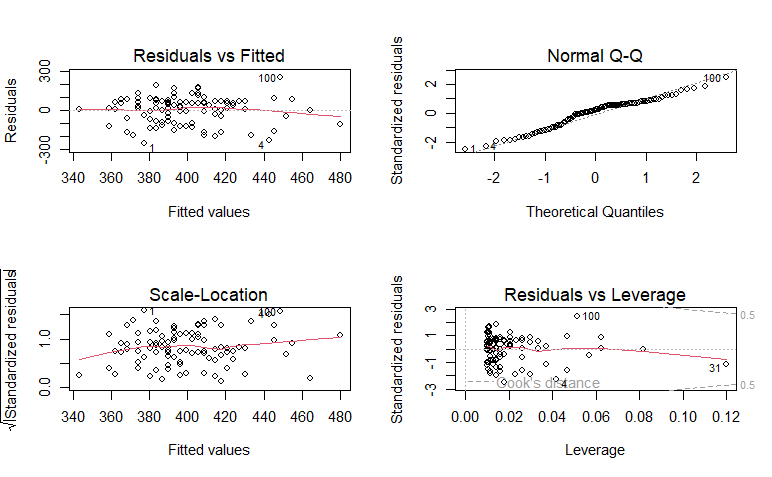

```r
par(mfrow=c(2,2))
plot(MWTBest1_AGE)
```

Checking the residual histogram :

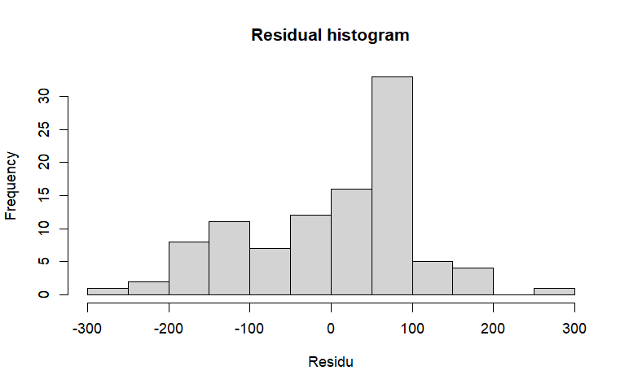

```r
hist(residualVals, main="Residual histogram", xlab = "Residu")
```

MULTIPLE LINEAR REGRESSION

Prediction walking distance using Age and FEV as predictors/variable :

```r
MWT1Best_FEV1_AGE <- lm(MWT1Best~FEV1+AGE, data = COPDStudentc.df)
```

```r
summary(MWT1Best_FEV1_AGE)
```

```
Call:
lm(formula = MWT1Best ~ FEV1 + AGE, data = COPDStudentc.df)

Residuals:
    Min      1Q  Median      3Q     Max
-233.13  -62.55   16.81   67.41  251.57

Coefficients:
            Estimate Std. Error t value Pr(>|t|)
(Intercept)  460.887     88.675   5.197 1.12e-06 ***
FEV1          71.278     13.909   5.125 1.52e-06 ***
AGE           -2.519      1.188  -2.121   0.0365 *
---
Signif. codes:  0 ‘***’ 0.001 ‘**’ 0.01 ‘*’ 0.05 ‘.’ 0.1 ‘ ’ 1

Residual standard error: 92.93 on 97 degrees of freedom
  (1 observation deleted due to missingness)
Multiple R-squared:  0.2547,    Adjusted R-squared:  0.2394
F-statistic: 16.58 on 2 and 97 DF,  p-value: 6.419e-07
```

```r
confint(MWT1Best_FEV1_AGE)
```

```
                 2.5 %      97.5 %
(Intercept) 284.892098 636.8819576
FEV1         43.672965  98.8837921
AGE          -4.877264  -0.1616972
```

Fit the model :

```r
predictedValsfevage <- predict(MWT1Best_FEV1_AGE)
residualValsfevage <- residuals(MWT1Best_FEV1_AGE)
```

Check using plots :

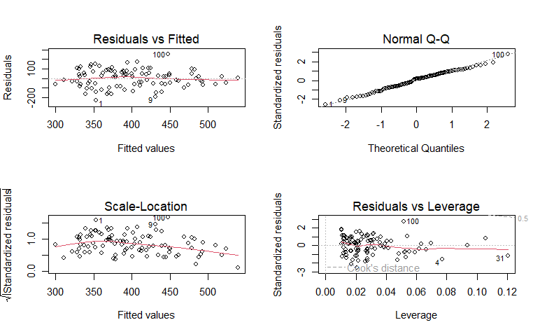

```r
par(mfrow=c(2,2))
plot(MWT1Best_FEV1_AGE)
```

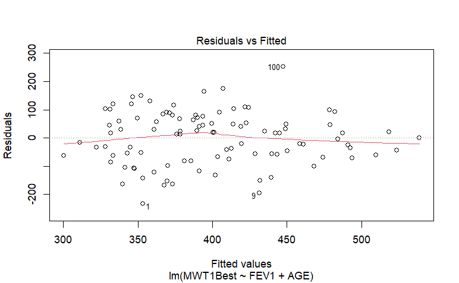

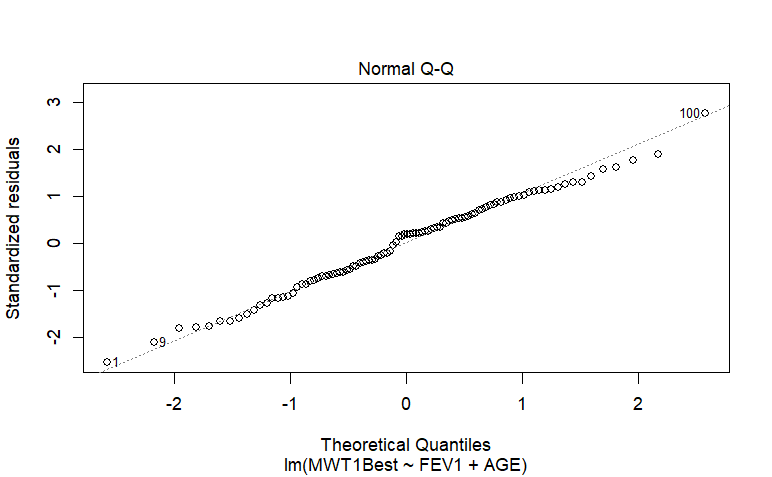

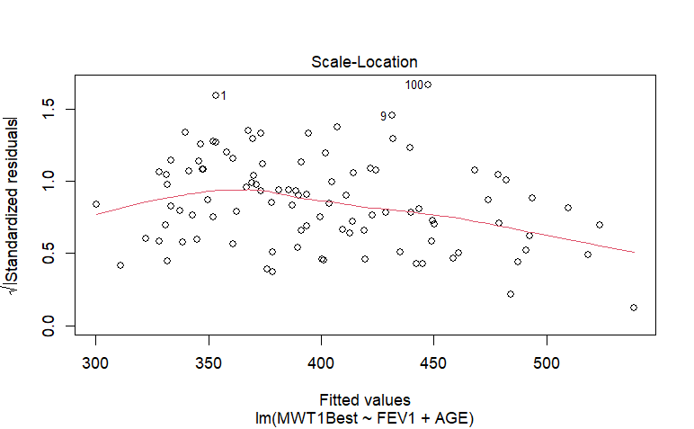

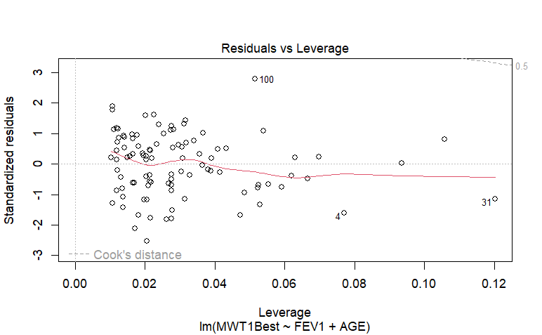

```r
plot(MWT1Best_FEV1_AGE)
```

Checking the residual histogram :

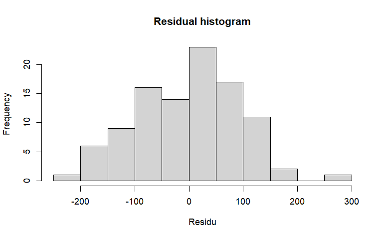

```r
hist(residualValsfevage, main="Residual histogram", xlab = "Residu")
```

Predict walking distance using FVC

```r
MWT1Best_FVC <- lm(MWT1Best~FVC, data=COPDStudentc.df)
```

```r
summary(MWT1Best_FVC)
```

```
Call:
lm(formula = MWT1Best ~ FVC, data = COPDStudentc.df)

Residuals:
     Min       1Q   Median       3Q      Max
-251.663  -66.598    6.364   63.539  246.125

Coefficients:
            Estimate Std. Error t value Pr(>|t|)
(Intercept)  254.951     30.779   8.283 6.28e-13 ***
FVC           48.630      9.866   4.929 3.37e-06 ***
---
Signif. codes:  0 ‘***’ 0.001 ‘**’ 0.01 ‘*’ 0.05 ‘.’ 0.1 ‘ ’ 1

Residual standard error: 95.87 on 98 degrees of freedom
  (1 observation deleted due to missingness)
Multiple R-squared:  0.1987,    Adjusted R-squared:  0.1905
F-statistic: 24.29 on 1 and 98 DF,  p-value: 3.368e-06
```

Fit the model :

```r
predictedValsfvc <- predict(MWT1Best_FVC)
residualValsfvc <- residuals(MWT1Best_FVC)
```

Check using plots :

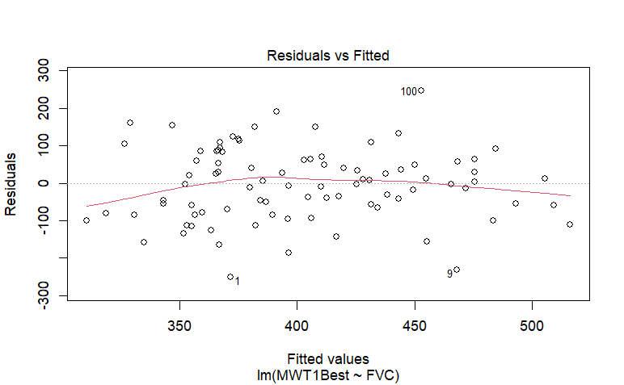

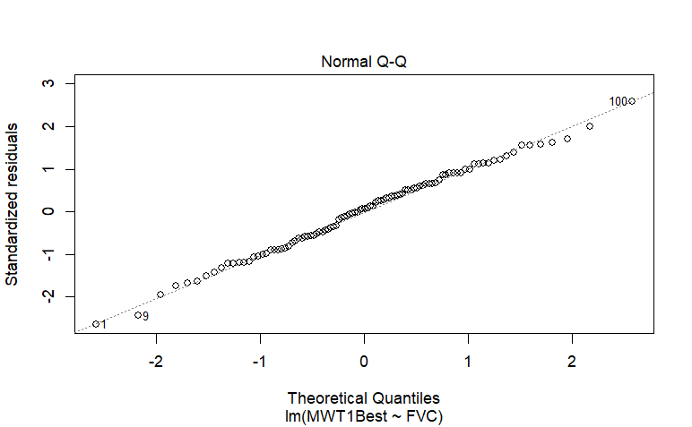

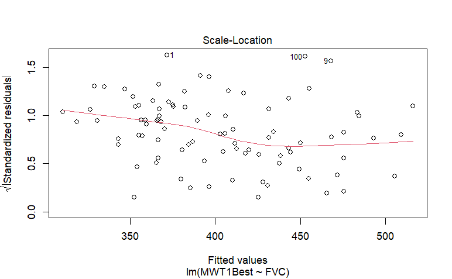

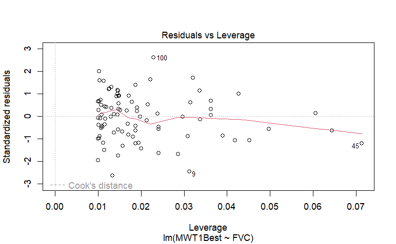

```r
plot(MWT1Best_FVC)
```

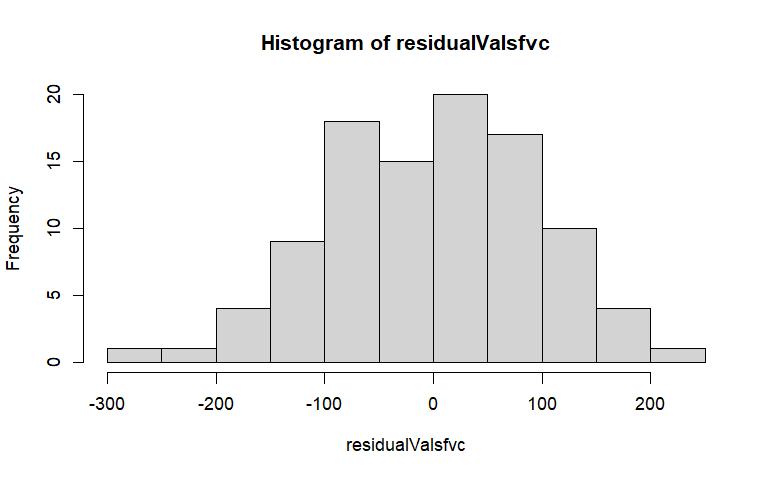

```r
hist(residualValsfvc)
```

Adding FVC as predictor

```r
MWT1Best_AGE_FVC <- lm(MWT1Best~AGE+FVC, data=COPDStudentc.df)
```

```r
summary(MWT1Best_AGE_FVC)
```

```
Call:
lm(formula = MWT1Best ~ AGE + FVC, data = COPDStudentc.df)

Residuals:
    Min      1Q  Median      3Q     Max
-236.89  -66.05   12.55   75.54  211.72

Coefficients:
            Estimate Std. Error t value Pr(>|t|)
(Intercept)  425.377     94.099   4.521 1.74e-05 ***
AGE           -2.325      1.215  -1.914   0.0586 .
FVC           46.058      9.827   4.687 9.06e-06 ***
---
Signif. codes:  0 ‘***’ 0.001 ‘**’ 0.01 ‘*’ 0.05 ‘.’ 0.1 ‘ ’ 1

Residual standard error: 94.59 on 97 degrees of freedom
  (1 observation deleted due to missingness)
Multiple R-squared:  0.2278,    Adjusted R-squared:  0.2119
F-statistic: 14.31 on 2 and 97 DF,  p-value: 3.588e-06
```

```r
confint(MWT1Best_AGE_FVC)
```

```
                 2.5 %       97.5 %
(Intercept) 238.616666 612.13818023
AGE          -4.736637   0.08649919
FVC          26.553107  65.56260023
```

Fit the model :

```r
predictedValsfvcage <- predict(MWT1Best_AGE_FVC)
residualValsfvcage <- residuals(MWT1Best_AGE_FVC)
```

Check using plots :

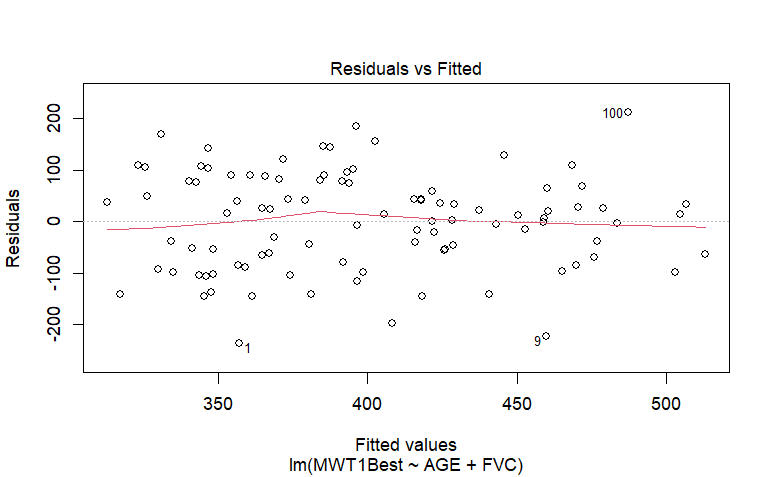

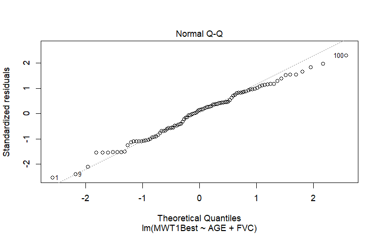

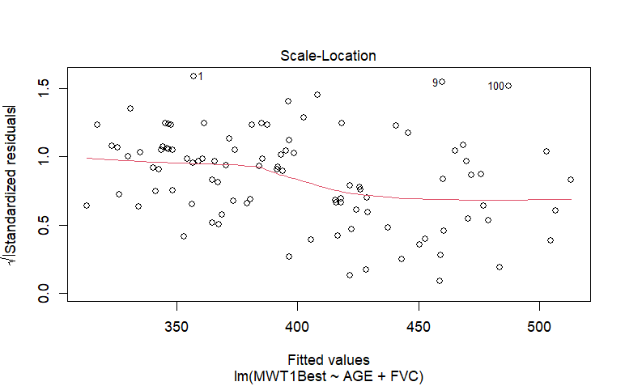

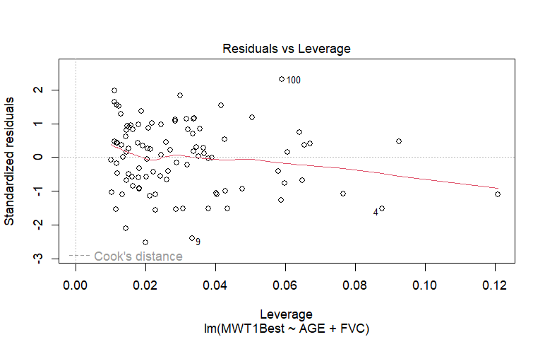

```r
plot(MWT1Best_AGE_FVC)
```

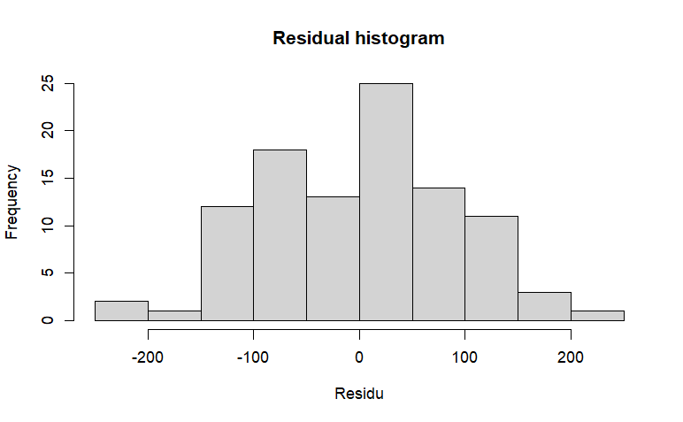

```r
hist(residualValsfvcage, main="Residual histogram", xlab = "Residu")
```

```r
MWT1Best_FEV1_FVC <- lm(MWT1Best~FEV1+FVC, data=COPDStudentc.df)
```

```r
summary(MWT1Best_FEV1_FVC)
```

```
Call:
lm(formula = MWT1Best ~ FEV1 + FVC, data = COPDStudentc.df)

Residuals:
     Min       1Q   Median       3Q      Max
-247.721  -65.796    1.112   62.348  271.823

Coefficients:
            Estimate Std. Error t value Pr(>|t|)
(Intercept)   258.43      30.34   8.517 2.11e-13 ***
FEV1           49.99      24.52   2.039   0.0442 *
FVC            20.34      16.94   1.201   0.2329
---
Signif. codes:  0 ‘***’ 0.001 ‘**’ 0.01 ‘*’ 0.05 ‘.’ 0.1 ‘ ’ 1

Residual standard error: 94.36 on 97 degrees of freedom
  (1 observation deleted due to missingness)
Multiple R-squared:  0.2316,    Adjusted R-squared:  0.2157
F-statistic: 14.62 on 2 and 97 DF,  p-value: 2.828e-06
```

```r
confint(MWT1Best_FEV1_FVC)
```

```
                 2.5 %    97.5 %
(Intercept) 198.204528 318.64886
FEV1          1.325636  98.65796
FVC         -13.283300  53.95358
```

Fit the model :

```r
predictedValsfevfvc <- predict(MWT1Best_FEV1_FVC)
residualValsfevfvc <- residuals(MWT1Best_FEV1_FVC)
```

Check using plots :

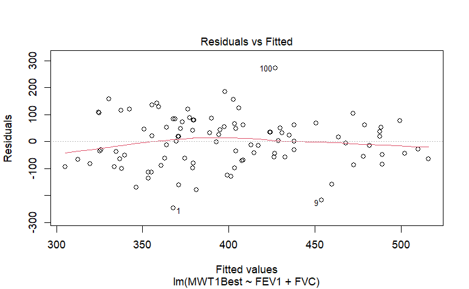

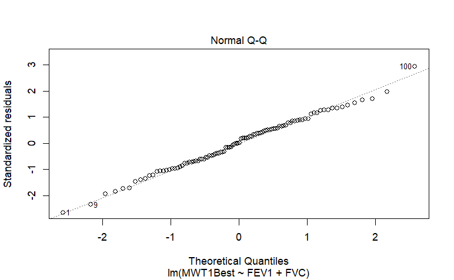

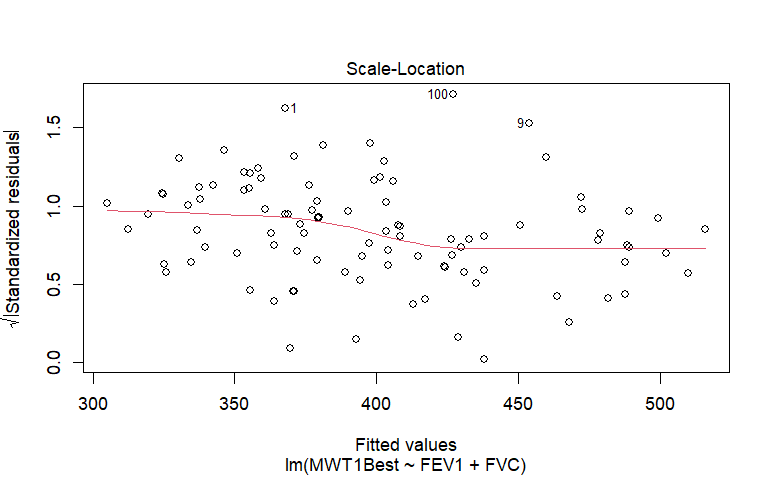

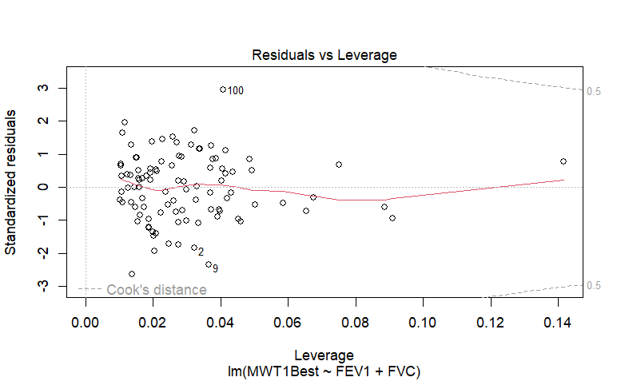

```r
plot(MWT1Best_FEV1_FVC)
```

```r
MWT1Best_AGE_FEV1_FVC <- lm(MWT1Best~FEV1+AGE+FVC, data=COPDStudentc.df)
```

```r
summary(MWT1Best_AGE_FEV1_FVC)
```

```
Call:
lm(formula = MWT1Best ~ FEV1 + AGE + FVC, data = COPDStudentc.df)

Residuals:
    Min      1Q  Median      3Q     Max
-232.38  -66.61   16.60   70.81  237.06

Coefficients:
            Estimate Std. Error t value Pr(>|t|)
(Intercept)  434.211     92.530   4.693 8.95e-06 ***
FEV1          51.363     24.156   2.126   0.0360 *
AGE           -2.397      1.194  -2.007   0.0475 *
FVC           16.907     16.767   1.008   0.3158
---
Signif. codes:  0 ‘***’ 0.001 ‘**’ 0.01 ‘*’ 0.05 ‘.’ 0.1 ‘ ’ 1

Residual standard error: 92.92 on 96 degrees of freedom
  (1 observation deleted due to missingness)
Multiple R-squared:  0.2625,    Adjusted R-squared:  0.2395
F-statistic: 11.39 on 3 and 96 DF,  p-value: 1.861e-06
```

```r
confint(MWT1Best_AGE_FEV1_FVC)
```

```
                 2.5 %       97.5 %
(Intercept) 250.540832 617.88064548
FEV1          3.413734  99.31189647
AGE          -4.767072  -0.02664541
FVC         -16.375423  50.19035475
```

Fit the model :

```r
predictedValsagefevfvc <- predict(MWT1Best_AGE_FEV1_FVC)
residualValsagefevfvc <- residuals(MWT1Best_AGE_FEV1_FVC)
```

Check using plots :

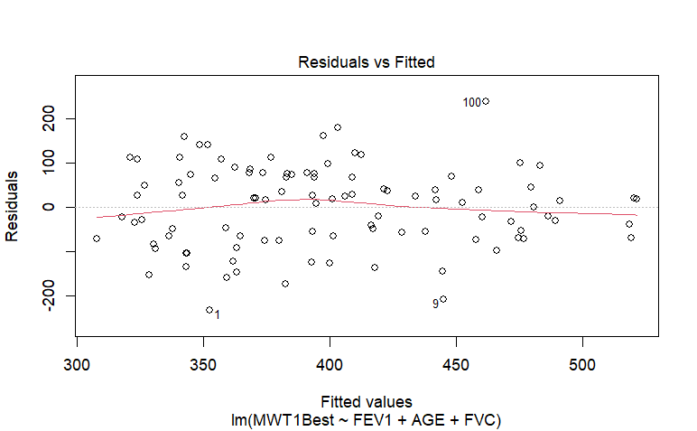

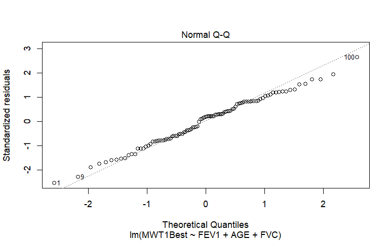

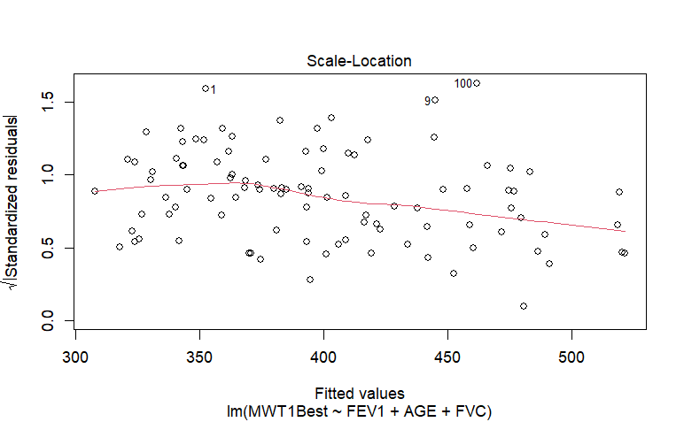

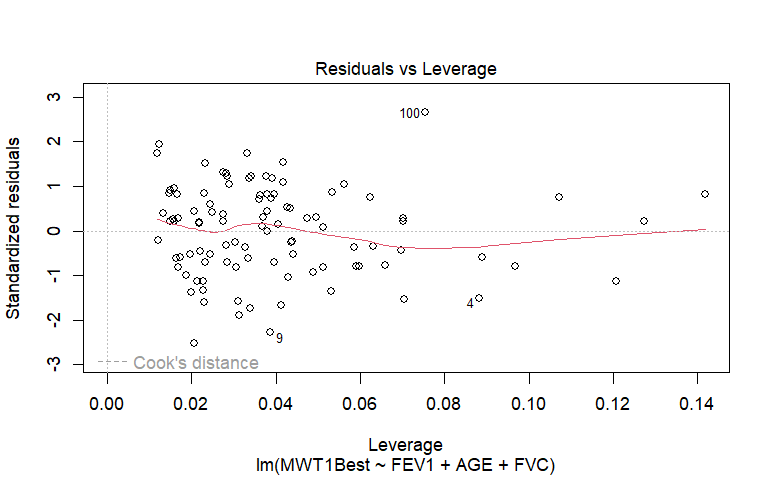

```r
plot(MWT1Best_AGE_FEV1_FVC)
```